# Task 1

## 1.0 Import Packages

```python
import matplotlib.pyplot as plt
import numpy as np
import pandas as pd
import sklearn
from sklearn.preprocessing import OneHotEncoder
from mlxtend.frequent_patterns import apriori, association_rules
from sklearn.preprocessing import OneHotEncoder
from sklearn.compose import make_column_transformer

import warnings
warnings.simplefilter("ignore")

path = "C:/Users/zklou/Documents/2022 summer/data mining/"
```

## 1.1 Data Importing and Cleaning

First, we import the data which were in three seperate CSV files, and merge them into one dataframe.

Then, since some of the numerical data are saved in string format of "74 bhp", we strip off the alphebetic parts and change data into correct data type.

```python
#read car data from three csv files and save as dataframe
tata_data = pd.read_csv(path + '/Tata.csv')
ford_data = pd.read_csv(path + '/Ford.csv')
honda_data = pd.read_csv(path + '/Honda.csv')

#merge three datasets into one
car_data = pd.concat([tata_data,ford_data],axis=0)
car_data = pd.concat([car_data,honda_data],axis=0)
print("There are {} samples and {} features in dataset".format(*car_data.shape))

#drop NA values
car_data = car_data.dropna()

#preview
car_data.head()
```

```
There are 398 samples and 13 features in dataset
```

|  | name | year | selling_price | km_driven | fuel | seller_type | transmission | owner | mileage | engine | max_power | torque | seats |
| --- | --- | --- | --- | --- | --- | --- | --- | --- | --- | --- | --- | --- | --- |
| 0 | Tata Bolt Quadrajet XE | 2017 | 450000 | 50000 | Diesel | Individual | Manual | First Owner | 22.95 kmpl | 1248 CC | 74 bhp | 190Nm@ 1750-3000rpm | 5.0 |
| 1 | Tata Bolt Quadrajet XE | 2017 | 450000 | 50000 | Diesel | Individual | Manual | First Owner | 22.95 kmpl | 1248 CC | 74 bhp | 190Nm@ 1750-3000rpm | 5.0 |
| 2 | Tata Bolt Quadrajet XE | 2017 | 600000 | 27000 | Diesel | Individual | Manual | First Owner | 22.95 kmpl | 1248 CC | 74 bhp | 190Nm@ 1750-3000rpm | 5.0 |
| 3 | Tata Bolt Quadrajet XM | 2017 | 600000 | 50000 | Diesel | Individual | Manual | First Owner | 22.95 kmpl | 1248 CC | 74 bhp | 190Nm@ 1750-3000rpm | 5.0 |
| 4 | Tata Bolt Revotron XE | 2017 | 350000 | 35000 | Petrol | Individual | Manual | First Owner | 17.57 kmpl | 1193 CC | 88.7 bhp | 140Nm@ 1500-4000rpm | 5.0 |

```python
#extract numerical values only
car_data.mileage = car_data.mileage.str.extract('(\d+)')
car_data.engine = car_data.engine.str.extract('(\d+)')
car_data.max_power = car_data.max_power.str.extract('(\d+)')

#turn dtype from object into numerical
car_data.mileage = car_data.mileage.astype(float)
car_data.engine = car_data.engine.astype(float)
car_data.max_power = car_data.max_power.astype(float)

#show data cleaning results
print(car_data.dtypes)
```

```
name              object
year               int64
selling_price      int64
km_driven          int64
fuel              object
seller_type       object
transmission      object
owner             object
mileage          float64
engine           float64
max_power        float64
torque            object
seats            float64
dtype: object
```

## 1.2 Data Selection and Processing

### 1.2.1 Data selection

Based on the head of data displaied below, we notice that variables "name" and "torque" may contain many nominal instances, so it is not practical to include these two variables in the association analysis.

```python
car_data.head()
```

|  | name | year | selling_price | km_driven | fuel | seller_type | transmission | owner | mileage | engine | max_power | torque | seats |
| --- | --- | --- | --- | --- | --- | --- | --- | --- | --- | --- | --- | --- | --- |
| 0 | Tata Bolt Quadrajet XE | 2017 | 450000 | 50000 | Diesel | Individual | Manual | First Owner | 22.0 | 1248.0 | 74.0 | 190Nm@ 1750-3000rpm | 5.0 |
| 1 | Tata Bolt Quadrajet XE | 2017 | 450000 | 50000 | Diesel | Individual | Manual | First Owner | 22.0 | 1248.0 | 74.0 | 190Nm@ 1750-3000rpm | 5.0 |
| 2 | Tata Bolt Quadrajet XE | 2017 | 600000 | 27000 | Diesel | Individual | Manual | First Owner | 22.0 | 1248.0 | 74.0 | 190Nm@ 1750-3000rpm | 5.0 |
| 3 | Tata Bolt Quadrajet XM | 2017 | 600000 | 50000 | Diesel | Individual | Manual | First Owner | 22.0 | 1248.0 | 74.0 | 190Nm@ 1750-3000rpm | 5.0 |
| 4 | Tata Bolt Revotron XE | 2017 | 350000 | 35000 | Petrol | Individual | Manual | First Owner | 17.0 | 1193.0 | 88.0 | 140Nm@ 1500-4000rpm | 5.0 |

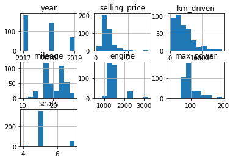

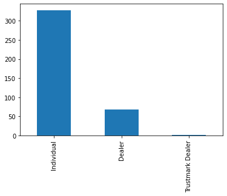

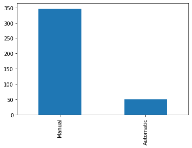

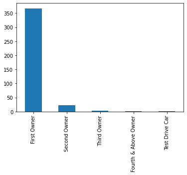

```python
#histogram for numerical varibles
numerical_var_names = ['year', 'selling_price', 'km_driven', 'mileage', 'engine', 'max_power', 'seats']
categorical_var_names = ['seller_type', 'transmission', 'owner']

#plot histograms for the rest variables
car_data.hist(column = numerical_var_names)
plt.show()

car_data[categorical_var_names[0]].value_counts().plot(kind='bar')
plt.show()
car_data[categorical_var_names[1]].value_counts().plot(kind='bar')
plt.show()
car_data[categorical_var_names[2]].value_counts().plot(kind='bar')
plt.show()
```

```python
#save to CSV format
all_var_names = list(car_data.columns)
all_var_names.remove('name')
all_var_names.remove('torque')
all_var_names.remove('owner')

car_select = car_data[all_var_names]
car_select.to_csv(path + " 100131001-100131002—T1Old.csv")
```

### 1.2.2 Data Discretization

Since there are some continuous variables such as "selling_price" or "mileage", we need to discreteze these variables. We first sort each condinuous data into one of five equal distance intervals, then use one-hot-coding to transform the initial dataset so that there are only 0s and 1s. We end up with a binary dataset with 38 columns.

```python
car_clean = car_data
#cont. variable into bins
cont_var_names = ['selling_price', 'km_driven', 'mileage', 'engine', 'max_power']
for var in cont_var_names:
    car_clean[var] = pd.cut(car_data[var], 5)
car_clean.head()
```

|  | name | year | selling_price | km_driven | fuel | seller_type | transmission | owner | mileage | engine | max_power | torque | seats |
| --- | --- | --- | --- | --- | --- | --- | --- | --- | --- | --- | --- | --- | --- |
| 0 | Tata Bolt Quadrajet XE | 2017 | (62816.0, 702800.0] | (33200.0, 65400.0] | Diesel | Individual | Manual | First Owner | (20.2, 23.6] | (1138.8, 1653.6] | (69.0, 101.0] | 190Nm@ 1750-3000rpm | 5.0 |
| 1 | Tata Bolt Quadrajet XE | 2017 | (62816.0, 702800.0] | (33200.0, 65400.0] | Diesel | Individual | Manual | First Owner | (20.2, 23.6] | (1138.8, 1653.6] | (69.0, 101.0] | 190Nm@ 1750-3000rpm | 5.0 |
| 2 | Tata Bolt Quadrajet XE | 2017 | (62816.0, 702800.0] | (839.0, 33200.0] | Diesel | Individual | Manual | First Owner | (20.2, 23.6] | (1138.8, 1653.6] | (69.0, 101.0] | 190Nm@ 1750-3000rpm | 5.0 |
| 3 | Tata Bolt Quadrajet XM | 2017 | (62816.0, 702800.0] | (33200.0, 65400.0] | Diesel | Individual | Manual | First Owner | (20.2, 23.6] | (1138.8, 1653.6] | (69.0, 101.0] | 190Nm@ 1750-3000rpm | 5.0 |
| 4 | Tata Bolt Revotron XE | 2017 | (62816.0, 702800.0] | (33200.0, 65400.0] | Petrol | Individual | Manual | First Owner | (16.8, 20.2] | (1138.8, 1653.6] | (69.0, 101.0] | 140Nm@ 1500-4000rpm | 5.0 |

```python
#one-hot-encoding data
transformer = make_column_transformer(
    (OneHotEncoder(), all_var_names),
    remainder='drop')
transformed = transformer.fit_transform(car_clean)

col_names = transformer.get_feature_names()
for i in range(len(all_var_names)):
        col_names = [sub.replace('onehotencoder__x'+ str(i),
                                 all_var_names[i]) for sub in col_names]
car_binary = pd.DataFrame(transformed.todense(), columns = col_names)
car_binary.head()
```

|  | year_2017 | year_2018 | year_2019 | selling_price_(62816.0, 702800.0] | selling_price_(702800.0, 1339600.0] | selling_price_(1339600.0, 1976400.0] | selling_price_(1976400.0, 2613200.0] | selling_price_(2613200.0, 3250000.0] | km_driven_(839.0, 33200.0] | km_driven_(33200.0, 65400.0] | ... | engine_(2168.4, 2683.2] | engine_(2683.2, 3198.0] | max_power_(36.84, 69.0] | max_power_(69.0, 101.0] | max_power_(101.0, 133.0] | max_power_(133.0, 165.0] | max_power_(165.0, 197.0] | seats_4.0 | seats_5.0 | seats_7.0 |
| --- | --- | --- | --- | --- | --- | --- | --- | --- | --- | --- | --- | --- | --- | --- | --- | --- | --- | --- | --- | --- | --- |
| 0 | 1.0 | 0.0 | 0.0 | 1.0 | 0.0 | 0.0 | 0.0 | 0.0 | 0.0 | 1.0 | ... | 0.0 | 0.0 | 0.0 | 1.0 | 0.0 | 0.0 | 0.0 | 0.0 | 1.0 | 0.0 |
| 1 | 1.0 | 0.0 | 0.0 | 1.0 | 0.0 | 0.0 | 0.0 | 0.0 | 0.0 | 1.0 | ... | 0.0 | 0.0 | 0.0 | 1.0 | 0.0 | 0.0 | 0.0 | 0.0 | 1.0 | 0.0 |
| 2 | 1.0 | 0.0 | 0.0 | 1.0 | 0.0 | 0.0 | 0.0 | 0.0 | 1.0 | 0.0 | ... | 0.0 | 0.0 | 0.0 | 1.0 | 0.0 | 0.0 | 0.0 | 0.0 | 1.0 | 0.0 |
| 3 | 1.0 | 0.0 | 0.0 | 1.0 | 0.0 | 0.0 | 0.0 | 0.0 | 0.0 | 1.0 | ... | 0.0 | 0.0 | 0.0 | 1.0 | 0.0 | 0.0 | 0.0 | 0.0 | 1.0 | 0.0 |
| 4 | 1.0 | 0.0 | 0.0 | 1.0 | 0.0 | 0.0 | 0.0 | 0.0 | 0.0 | 1.0 | ... | 0.0 | 0.0 | 0.0 | 1.0 | 0.0 | 0.0 | 0.0 | 0.0 | 1.0 | 0.0 |

5 rows × 38 columns

```python
#save to CSV format
car_binary.to_csv(path + "100131001-100131002—T1Disc.csv")
```

## 1.3 Data Analysis

### 1.3.1 Most Frequent Item-Sets

Below are the suppport and contend for the 10 most frequent itemsets. Note that since some itemsets are not displayed completely in the dataframe format, we printed complete itemsets below.

```python
#calculate frequent item-sets
freq_items = apriori(car_binary, min_support = 0.05, use_colnames = True)

#delete all itemsets < 2
two_freq_items = freq_items.copy(deep = True)
del_list = []
for i in range(freq_items.shape[0]):
    if len(list(freq_items.iloc[i, 1])) <= 1:
        del_list.append(i)
two_freq_items.drop(del_list, axis = 0, inplace = True)

#sorting and displaying
two_freq_items.sort_values(by = 'support', ascending=False).head(10)
```

|  | support | itemsets |
| --- | --- | --- |
| 207 | 0.818640 | (seats_5.0, engine_(1138.8, 1653.6]) |
| 190 | 0.780856 | (seats_5.0, transmission_Manual) |
| 184 | 0.753149 | (transmission_Manual, engine_(1138.8, 1653.6]) |
| 166 | 0.743073 | (transmission_Manual, seller_type_Individual) |
| 822 | 0.732997 | (transmission_Manual, engine_(1138.8, 1653.6],... |
| 176 | 0.727960 | (seats_5.0, seller_type_Individual) |
| 170 | 0.697733 | (engine_(1138.8, 1653.6], seller_type_Individual) |
| 800 | 0.685139 | (seats_5.0, engine_(1138.8, 1653.6], seller_ty... |
| 783 | 0.664987 | (seats_5.0, transmission_Manual, seller_type_I... |
| 205 | 0.644836 | (engine_(1138.8, 1653.6], max_power_(69.0, 101... |

```python
#format for better visualization
for i in range(10):
    print('Itemset' + str(i) + ": " + str(two_freq_items.sort_values(by = 'support', ascending=False).iloc[i, 1]))
```

```
Itemset0: frozenset({'seats_5.0', 'engine_(1138.8, 1653.6]'})
Itemset1: frozenset({'seats_5.0', 'transmission_Manual'})
Itemset2: frozenset({'transmission_Manual', 'engine_(1138.8, 1653.6]'})
Itemset3: frozenset({'transmission_Manual', 'seller_type_Individual'})
Itemset4: frozenset({'transmission_Manual', 'engine_(1138.8, 1653.6]', 'seats_5.0'})
Itemset5: frozenset({'seats_5.0', 'seller_type_Individual'})
Itemset6: frozenset({'engine_(1138.8, 1653.6]', 'seller_type_Individual'})
Itemset7: frozenset({'seats_5.0', 'engine_(1138.8, 1653.6]', 'seller_type_Individual'})
Itemset8: frozenset({'seats_5.0', 'transmission_Manual', 'seller_type_Individual'})
Itemset9: frozenset({'engine_(1138.8, 1653.6]', 'max_power_(69.0, 101.0]'})
```

### 1.3.2 Association Rules

Below are the 5 most confident association rules and the 5 least confident rules. Note that since some rules are not displayed completely in the dataframe format, we printed complete itemsets below.

The confidence for the top 5 rules are all 1. The confidence for all bottom 5 rules are 0.057.

```python
#calculate association rules
rules = association_rules(freq_items, metric ="lift", min_threshold = 1)

#sort and display rules based on confidence level
rules = rules.sort_values(['confidence', 'lift'], ascending =[False, False])
rules.head()
```

|  | antecedents | consequents | antecedent support | consequent support | support | confidence | lift | leverage | conviction |
| --- | --- | --- | --- | --- | --- | --- | --- | --- | --- |
| 14978 | (mileage_(16.8, 20.2], engine_(2168.4, 2683.2]) | (max_power_(133.0, 165.0], seats_7.0) | 0.055416 | 0.073048 | 0.055416 | 1.0 | 13.689655 | 0.051368 | inf |
| 45624 | (engine_(2168.4, 2683.2], mileage_(16.8, 20.2]... | (max_power_(133.0, 165.0], seats_7.0) | 0.055416 | 0.073048 | 0.055416 | 1.0 | 13.689655 | 0.051368 | inf |
| 45638 | (mileage_(16.8, 20.2], engine_(2168.4, 2683.2]) | (max_power_(133.0, 165.0], seats_7.0, fuel_Die... | 0.055416 | 0.073048 | 0.055416 | 1.0 | 13.689655 | 0.051368 | inf |
| 47078 | (seller_type_Individual, mileage_(16.8, 20.2],... | (max_power_(133.0, 165.0], seats_7.0) | 0.050378 | 0.073048 | 0.050378 | 1.0 | 13.689655 | 0.046698 | inf |
| 97995 | (fuel_Diesel, seller_type_Individual, mileage_... | (max_power_(133.0, 165.0], seats_7.0) | 0.050378 | 0.073048 | 0.050378 | 1.0 | 13.689655 | 0.046698 | inf |

```python
rules.tail()
```

|  | antecedents | consequents | antecedent support | consequent support | support | confidence | lift | leverage | conviction |
| --- | --- | --- | --- | --- | --- | --- | --- | --- | --- |
| 53983 | (seats_5.0) | (transmission_Manual, year_2017, max_power_(69... | 0.879093 | 0.055416 | 0.050378 | 0.057307 | 1.034123 | 0.001662 | 1.002006 |
| 54024 | (seats_5.0) | (engine_(1138.8, 1653.6], year_2017, max_power... | 0.879093 | 0.055416 | 0.050378 | 0.057307 | 1.034123 | 0.001662 | 1.002006 |
| 54050 | (seats_5.0) | (transmission_Manual, engine_(1138.8, 1653.6],... | 0.879093 | 0.055416 | 0.050378 | 0.057307 | 1.034123 | 0.001662 | 1.002006 |
| 76403 | (seats_5.0) | (transmission_Manual, seller_type_Individual, ... | 0.879093 | 0.055416 | 0.050378 | 0.057307 | 1.034123 | 0.001662 | 1.002006 |
| 108164 | (seats_5.0) | (transmission_Manual, engine_(1138.8, 1653.6],... | 0.879093 | 0.055416 | 0.050378 | 0.057307 | 1.034123 | 0.001662 | 1.002006 |

```python
#format for better visualization
print("==========================Five Most Confident Associative Rules:==========================")
for i in range(5):
    print("Rule" + str(i+1) + ":")
    print(str(rules.iloc[i, 0]) + "->\n" + str(rules.iloc[i, 1]) + "\n")

print("==========================Five Least Confident Associative Rules==========================")
for i in range(1, 6):
    print("Rule" + str(5-i) + ":")
    print(str(rules.iloc[-i, 0]) + "->\n" + str(rules.iloc[-i, 1]) + "\n")
```

```
==========================Five Most Confident Associative Rules:==========================
Rule1:
frozenset({'mileage_(16.8, 20.2]', 'engine_(2168.4, 2683.2]'})->
frozenset({'max_power_(133.0, 165.0]', 'seats_7.0'})

Rule2:
frozenset({'engine_(2168.4, 2683.2]', 'mileage_(16.8, 20.2]', 'fuel_Diesel'})->
frozenset({'max_power_(133.0, 165.0]', 'seats_7.0'})

Rule3:
frozenset({'mileage_(16.8, 20.2]', 'engine_(2168.4, 2683.2]'})->
frozenset({'max_power_(133.0, 165.0]', 'seats_7.0', 'fuel_Diesel'})

Rule4:
frozenset({'seller_type_Individual', 'mileage_(16.8, 20.2]', 'engine_(2168.4, 2683.2]'})->
frozenset({'max_power_(133.0, 165.0]', 'seats_7.0'})

Rule5:
frozenset({'fuel_Diesel', 'seller_type_Individual', 'mileage_(16.8, 20.2]', 'engine_(2168.4, 2683.2]'})->
frozenset({'max_power_(133.0, 165.0]', 'seats_7.0'})

==========================Five Least Confident Associative Rules==========================
Rule4:
frozenset({'seats_5.0'})->
frozenset({'transmission_Manual', 'engine_(1138.8, 1653.6]', 'selling_price_(702800.0, 1339600.0]', 'max_power_(69.0, 101.0]', 'year_2017', 'fuel_Diesel'})

Rule3:
frozenset({'seats_5.0'})->
frozenset({'transmission_Manual', 'seller_type_Individual', 'km_driven_(839.0, 33200.0]', 'year_2019', 'mileage_(16.8, 20.2]'})

Rule2:
frozenset({'seats_5.0'})->
frozenset({'transmission_Manual', 'engine_(1138.8, 1653.6]', 'selling_price_(702800.0, 1339600.0]', 'max_power_(69.0, 101.0]', 'year_2017'})

Rule1:
frozenset({'seats_5.0'})->
frozenset({'engine_(1138.8, 1653.6]', 'year_2017', 'max_power_(69.0, 101.0]', 'selling_price_(702800.0, 1339600.0]', 'fuel_Diesel'})

Rule0:
frozenset({'seats_5.0'})->
frozenset({'transmission_Manual', 'year_2017', 'max_power_(69.0, 101.0]', 'selling_price_(702800.0, 1339600.0]', 'fuel_Diesel'})
```

### 1.3.3 Measures of Interest

Here we choose Interst, Cosine, Piatesky_Shapiro, Jaccard, All-confidence as our 5 different measures of interest. Results are displayed below in the same order as the section above.

```python
#helper function that takes in a rule and calculate 5 MOIs
def get_moi(ante, conse):
    N = car_binary.shape[0]
    #f1+
    res_1p = np.ones(N)
    for condition in list(ante):
        res_1p = np.logical_and(res_1p, car_binary[condition])
    f_1p = np.sum(res_1p)
    #f+1
    res_p1 = np.ones(car_binary.shape[0])
    for condition in list(conse):
        res_p1 = np.logical_and(res_p1, car_binary[condition])
    f_p1 = np.sum(res_p1)
    #f11
    res_11 = np.logical_and(res_1p, res_p1)
    f_11 = np.sum(res_11)

    moi = [0, 0, 0, 0, 0]
    #interest
    moi[0] = N*f_11/f_1p/f_p1
    #cosine
    moi[1] = f_11/np.sqrt(f_1p * f_p1)
    #Piatetsky_Shapiro
    moi[2] = f_11/N - (f_1p * f_p1/(N^2))
    #Jaccard
    moi[3] = f_11/(f_1p + f_p1 - f_11)
    #all-confidence
    moi[4] = min(f_11/f_1p, f_11/f_p1)

    return moi
```

```python
moi_df = pd.DataFrame(columns = ('Interst', 'Cosine', 'Piatesky_Shapiro', 'Jaccard', 'All-confidence'))
for i in range(5):
    moi = get_moi(rules.iloc[i, 0], rules.iloc[i, 1])
    moi_df.loc[len(moi_df.index)] = moi

print(moi_df)
```

```
     Interst    Cosine  Piatesky_Shapiro   Jaccard  All-confidence
0  13.689655  0.870988         -1.543582  0.758621        0.758621
1  13.689655  0.870988         -1.543582  0.758621        0.758621
2  13.689655  0.870988         -1.543582  0.758621        0.758621
3  13.689655  0.830455         -1.403256  0.689655        0.689655
4  13.689655  0.830455         -1.403256  0.689655        0.689655
```